# Assignment 03 - Fitting and Validating Poisson Point Process Models

Dhun Sheth

16 April, 2024 20:21:11

Complete the following exercises within the lab period and submit to Canvas before leaving. In addition to the points detailed below, 5 points are assigned to the quality of the annotation and to the ‘cleanliness’ of the code and resulting pdf document.

## Exercise 1 – 1 point

We will again be working with the BC Parks dataset, which contains information on the locations of Provincial Parks in British Columbia. The parks belong to 5 different regions. There is also information on elevation (in m) and percent forest cover contained within the dataset.

- Import the BC park locations dataset and convert the data to a `ppp` object (for today you can exclude information on regions). – 1 point(s)

Note: You will need to load the `maptools` package and make use of the `as.owin()` function.

### Loading Data and Packages

```r
load('BC_Parks.Rda')
parks_data <- DATA
load('BC_Covariates.Rda')
library(viridis)
library(colorspace)
library(spatstat)
library(sf)
library(raster)
#library(maptools)
```

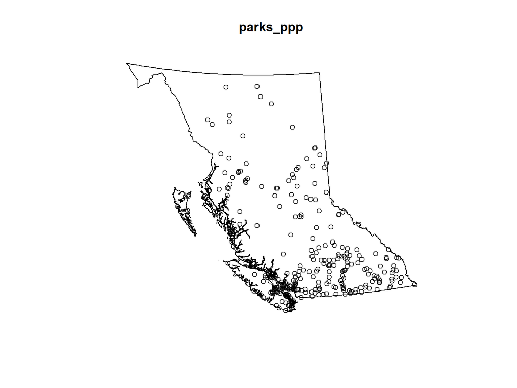

```r
# Window

parks_win <- as.owin(parks_data$Window)

# Converting data to ppp object
parks_ppp <- ppp(x = parks_data$Parks$X, # X coordinates
                    y = parks_data$Parks$Y, # Y coordinates
                    window = parks_win) # Observation window

plot(parks_ppp)
```

## Exercise 2 – 4 points

- Estimate and plot $\rho$ for the locations of parks as a function of both elevation and forest cover (be sure that the x-axis for elevation does not go below 0). – 2 point(s)
- Check for collinearity between elevation and forest cover (you will need to consider NA values). – 1 point(s)
- Based on these initial analyses, write down the expected form of the model. Provide justification for this starting point. – 1 point(s)

Note: Estimating rho can be slow ($\sim$ 1-2 min). Be sure to leave enough time for the document to knit.

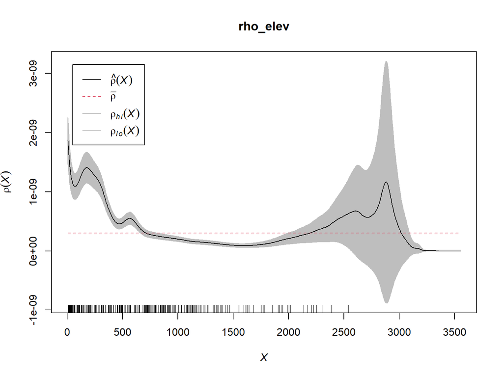

```r
# Estimate Rho
rho_elev <- rhohat(parks_ppp, DATA$Elevation)

plot(rho_elev, xlim = c(0, max(rho_elev$X)))
```

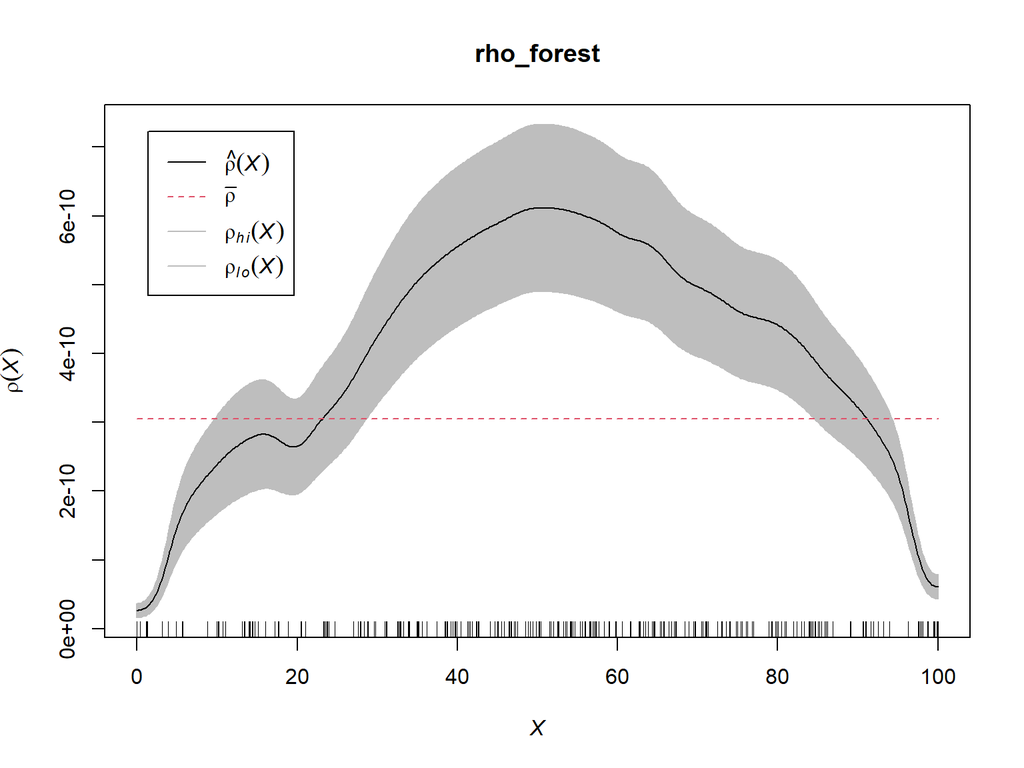

```r
rho_forest <- rhohat(parks_ppp, DATA$Forest)

plot(rho_forest)
```

```r
# Collinearity

cor.im(DATA[[2]], DATA[[3]], use = 'complete.obs')
```

```
##           ..1       ..2
## ..1  1.000000 -0.248819
## ..2 -0.248819  1.000000
```

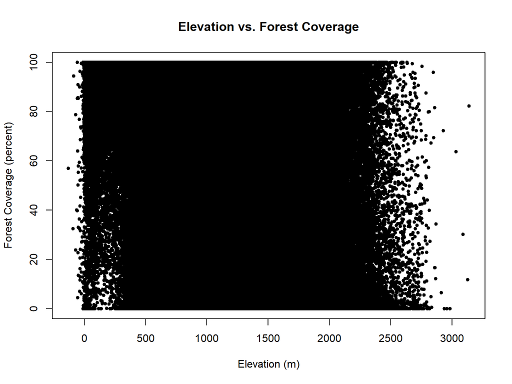

```r
elevation_values <- DATA$Elevation$v
forest_values <- DATA$Forest$v

# Determine the number of rows and columns
num_rows <- dim(elevation_values)[1]
num_cols <- dim(elevation_values)[2]

# Create a raster object
elevation_raster <- raster(nrows = num_rows, ncols = num_cols)

values(elevation_raster) <- elevation_values

# Rows and cols for forest raster object
num_rows <- dim(forest_values)[1]
num_cols <- dim(forest_values)[2]

forest_raster <- raster(nrows = num_rows, ncols = num_cols)

values(forest_raster) <- forest_values

# Resize the forest raster to match the elevation raster
forest_resized <- resample(forest_raster, elevation_raster, method = "bilinear")

# Plot
elevation_values <- values(elevation_raster)
forest_values <- values(forest_resized)
valid_indices <- !is.na(elevation_values) & !is.na(forest_values)
elevation_clean <- elevation_values[valid_indices]
forest_clean <- forest_values[valid_indices]

plot(elevation_clean,
     forest_clean,
     xlab = "Elevation (m)",
     ylab = "Forest Coverage (percent)",
     main = "Elevation vs. Forest Coverage",
     pch = 20)
```

Based on the initial analysis and looking at the rho estimates plotted above, they are somewhat quadratic (espically rho forest) and so an intial starting model can be:  
$\lambda(u)=e^{\beta_0 + \beta_1*Elevation(u) + \beta_2*Elevation(u)^2 +\beta_3*Forest(u) + \beta_4*Forest(u)^2}$

## Exercise 3 – 4 points

- Fit the model you have defined in exercise 2 and inspect the model output. – 1 point(s)
- Fit a null, intercept only model. – 1 point(s)
- Use AIC and a likelihood ratio test to determine if the model you defined is a better fit than the intercept only model. – 1 point(s)
- Write down the equation for the selected model. – 0.5 point(s)
- Use this equation to estimate the intensity of parks at 500m elevation and 50% forest cover.

```r
fit <- ppm(parks_ppp ~ Elevation + I(Elevation^2) + Forest + I(Forest^2), data = DATA)

fit
```

```
## Nonstationary Poisson process
## Fitted to point pattern dataset 'parks_ppp'
##
## Log intensity:  ~Elevation + I(Elevation^2) + Forest + I(Forest^2)
##
## Fitted trend coefficients:
##    (Intercept)      Elevation I(Elevation^2)         Forest    I(Forest^2)
##  -2.072331e+01  -3.934276e-03   1.391814e-06   4.801032e-02  -4.388615e-04
##
##                     Estimate         S.E.       CI95.lo       CI95.hi Ztest
## (Intercept)    -2.072331e+01 2.347706e-01 -2.118345e+01 -2.026316e+01   ***
## Elevation      -3.934276e-03 2.743954e-04 -4.472081e-03 -3.396471e-03   ***
## I(Elevation^2)  1.391814e-06 1.290279e-07  1.138924e-06  1.644705e-06   ***
## Forest          4.801032e-02 7.980056e-03  3.236970e-02  6.365094e-02   ***
## I(Forest^2)    -4.388615e-04 7.377901e-05 -5.834657e-04 -2.942573e-04   ***
##                      Zval
## (Intercept)    -88.270436
## Elevation      -14.337981
## I(Elevation^2)  10.786925
## Forest           6.016289
## I(Forest^2)     -5.948325
```

Coefficients are all statistically significant.

```r
# Null or intercept only model
null_fit <- ppm(parks_ppp ~ 1, data = DATA)

null_fit
```

```
## Stationary Poisson process
## Fitted to point pattern dataset 'parks_ppp'
## Intensity: 3.04768e-10
##              Estimate       S.E.   CI95.lo   CI95.hi Ztest     Zval
## log(lambda) -21.91147 0.05882353 -22.02676 -21.79618   *** -372.495
```

```r
# AIC and LR test

# AIC values
f <- AIC(fit)
print(f)
```

```
## [1] 12956.11
```

```r
nf <- AIC(null_fit)
print(nf)
```

```
## [1] 13244.83
```

```r
change <- AIC(null_fit) - AIC(fit)
print(change)
```

```
## [1] 288.7193
```

```r
# LR
anova (null_fit, fit, test = "LR")
```

|  | Npar | Df | Deviance | Pr(>Chi) |
| --- | --- | --- | --- | --- |
| 1 | 1 | NA | NA | NA |
| 2 | 5 | 4 | 294.7352 | 1.480452e-62 |

Based on the change in AIC being 288.719257>0, the extra complexity is well supported by the data.

In addition, based on the likelihood ratio test, the p-value is very small, indicating we should reject the simple model in favor of the more complex one.

## Exercise 4 – 4 points

- Visualise the fitted model. Note: log scale the estimated intensity when plotting, ignore the standard error. You can use the `n` argument to adjust the resolution – 1 point(s)
- Plot the effects of the individual coefficients. Note: use the median value(s) of the other coefficients. – 2 point(s)
- Visually, do you think the model predictions are a good match to the data? – 1 point(s)

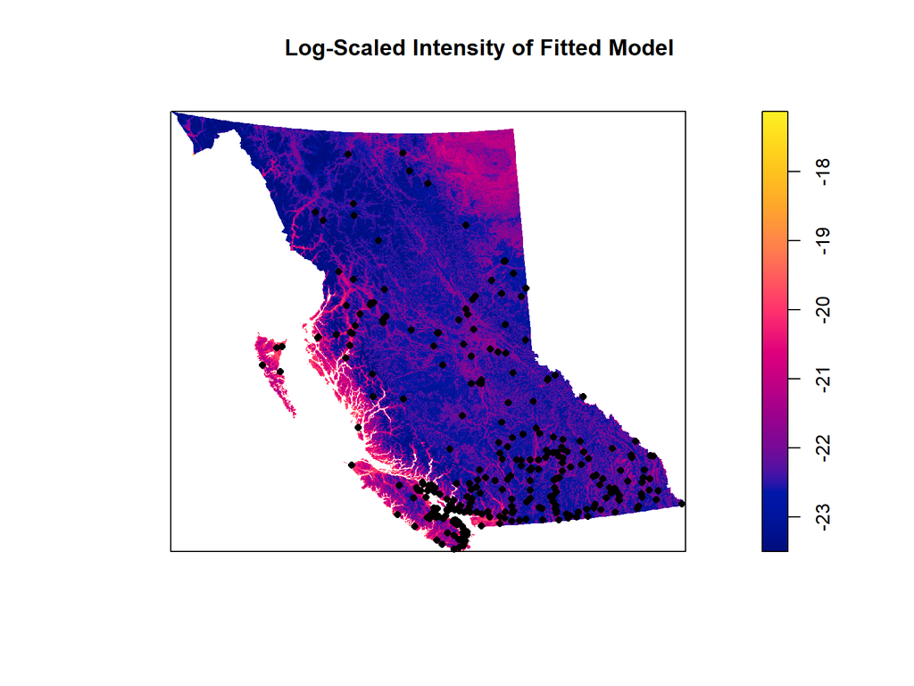

```r
# Visualizing fitted model
predicted_intensity <- predict(fit, type="intensity", n=1000)

log_intensity <- log(predicted_intensity)

plot(log_intensity, main="Log-Scaled Intensity of Fitted Model")

plot(parks_ppp, add=TRUE, pch=16, cex=0.8, col="black")
```

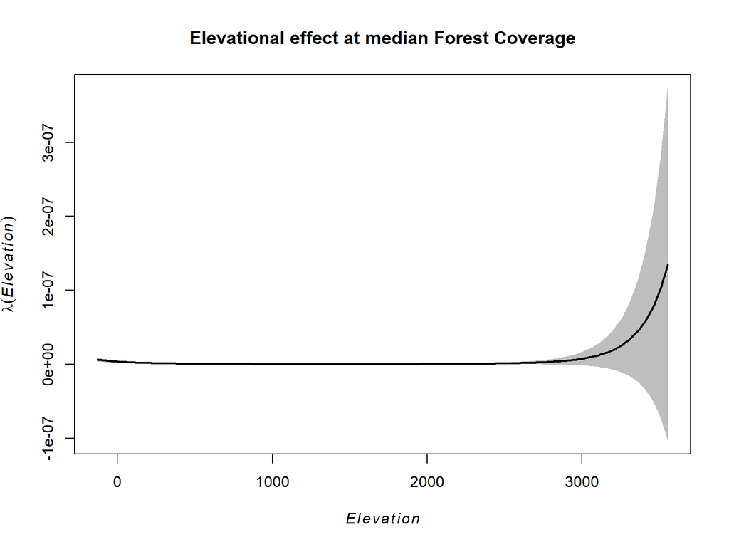

```r
median_forest <- median(DATA$Forest)

# Elevational effect on lambda at median forest coverage
elev_effect <- effectfun(fit, "Elevation", Forest = median_forest, se.fit = T)

median_elev <- median(DATA$Elevation)

# Forest coverage effect on lambda at median elevation
forest_effect <- effectfun(fit, "Forest", Elevation = median_elev, se.fit = T)

#Plot the elevation effect
plot(elev_effect,
     legend = FALSE,
     lwd = 2,
     main = "Elevational effect at median Forest Coverage")
```

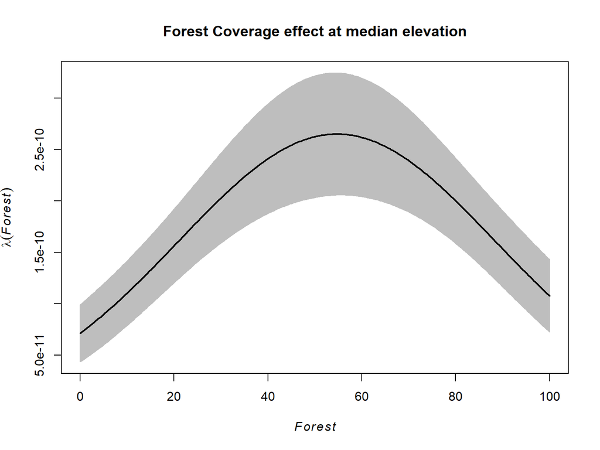

```r
#Plot the slope effect
plot(forest_effect,
     legend = FALSE,
     lwd = 2,
     main = "Forest Coverage effect at median elevation")
```

Looking at the log-scale fitted model, it seems okay, but can definitely use some improvements, particularly, in the top right corner showing high intensity when there is only a few parks nearby.